# using microdata and semantic html to represent python objects

In [ ]

markdown

actions

```
# using microdata and semantic html to represent python objects

microdata attributes exist to append metadata to html elements.
it is possible to use [microdata] to describe python types,
and in doing so we have standard selectors for styling python objects.
lists, sequences, and containers can and should be summarized by screen reader technology.
the outcome of these codes great accessible representation of common python objects that are assistive to assistive technology users.


![image.png](attachment:931392ee-8c73-455a-ac4f-7f7d02c45d72.png)
```

11

# using microdata and semantic html to represent python objects

microdata attributes exist to append metadata to html elements. it is possible to use [microdata] to describe python types, and in doing so we have standard selectors for styling python objects. lists, sequences, and containers can and should be summarized by screen reader technology. the outcome of these codes great accessible representation of common python objects that are assistive to assistive technology users.

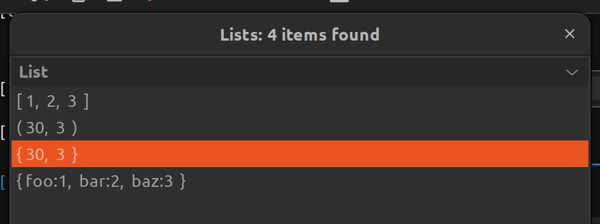

In [ 1 ]

code

actions

```
    import midgy
```

1

In [ ]

markdown

actions

```
https://www.tpgi.com/making-numbers-in-web-content-accessible/
```

1

https://www.tpgi.com/making-numbers-in-web-content-accessible/

In [ ]

markdown

actions

```
https://developer.mozilla.org/en-US/docs/Web/HTML/Element/time
```

1

https://developer.mozilla.org/en-US/docs/Web/HTML/Element/time

In [ 155 ]

code

actions

````
%%
## representing constants

there are python constants that have most natural respresentations use the [`data`](https://developer.mozilla.org/en-US/docs/Web/HTML/Element/data)s tag.

```html
<data value="true">True</data>,
<data value="false">False</data>,
<data value>None</data>,
<style>
data[value] {
    /**recapture the style used in the code editor for the constants.**/
    font-family: monospace;
    color: var(--jp-mirror-editor-keyword-color, green);
    font-weight: bold;
}
</style>
```
````

18

## representing constants

there are python constants that have most natural respresentations use the [`data`](https://developer.mozilla.org/en-US/docs/Web/HTML/Element/data) s tag.

```html
<data value="true">True</data>,
<data value="false">False</data>,
<data value>None</data>,
<style>
data[value] {
    /**recapture the style used in the code editor for the constants.**/
    font-family: monospace;
    color: var(--jp-mirror-editor-keyword-color, green);
    font-weight: bold;
}
</style>
```

True , False , None ,

In [ 156 ]

code

actions

````
%%
## representing strings

https://developer.mozilla.org/en-US/docs/Web/HTML/Element/samp

```html
<samp itemscope itemtype="https://docs.python.org/3/library/functions.html#str">a string representation makes sense as a samp</samp>
<br/>
<samp itemscope itemtype="https://docs.python.org/3/library/functions.html#str" style="--nb-quote-style: var(--nb-single-quote);">a single quoted string</samp>

<style>
:root {
    /**its hard to write quotes inside of html tags so it helps to have constants to use.**/
    --nb-single-quote: "'";
    --nb-double-quote: "\"";
    --nb-quote-style: var(--nb-double-quote);
}
samp[itemtype$="str"] {
    &::before, &::after {content: var(--nb-quote-style);}
}
</style>
```
````

22

## representing strings

https://developer.mozilla.org/en-US/docs/Web/HTML/Element/samp

```html
<samp itemscope itemtype="https://docs.python.org/3/library/functions.html#str">a string representation makes sense as a samp</samp>
<br/>
<samp itemscope itemtype="https://docs.python.org/3/library/functions.html#str" style="--nb-quote-style: var(--nb-single-quote);">a single quoted string</samp>

<style>
:root {
    /**its hard to write quotes inside of html tags so it helps to have constants to use.**/
    --nb-single-quote: "'";
    --nb-double-quote: "\"";
    --nb-quote-style: var(--nb-double-quote);
}
samp[itemtype$="str"] {
    &::before, &::after {content: var(--nb-quote-style);}
}
</style>
```

`a string representation makes sense as a samp`  
`a single quoted string`

In [ 157 ]

code

actions

````
%%
## representing numbers


https://developer.mozilla.org/en-US/docs/Web/HTML/Element/samp

```html
<samp itemscope itemtype="https://docs.python.org/3/library/functions.html#int">42</samp>
<br/>
<samp itemscope itemtype="https://docs.python.org/3/library/functions.html#float">3.141596</samp>
```
````

11

## representing numbers

https://developer.mozilla.org/en-US/docs/Web/HTML/Element/samp

```html
<samp itemscope itemtype="https://docs.python.org/3/library/functions.html#int">42</samp>
<br/>
<samp itemscope itemtype="https://docs.python.org/3/library/functions.html#float">3.141596</samp>
```

`42`  
`3.141596`

In [ ]

markdown

actions

```
## representing containers
```

1

## representing containers

In [ ]

markdown

actions

```
containers allow presenting multiple constants, strings, numbers, or other containers.
```

1

containers allow presenting multiple constants, strings, numbers, or other containers.

In [ 159 ]

code

actions

````
%%
### representing lists


```html
<ol itemscope itemtype="https://docs.python.org/3/library/functions.html#list">
    <li>1</li><li>2</li><li>3</li>
</ol>
<style>
ol[itemtype$="#list"] {
    font-family: mono-space;
    li {
        display: inline-block;
        &:not(:last-child)::after {content: ",";}
    }
    list-style: none;
    &::before {content: "[";}
    &::after {content: "]";}
}
</style>
```
````

21

### representing lists

```html
<ol itemscope itemtype="https://docs.python.org/3/library/functions.html#list">
    <li>1</li><li>2</li><li>3</li>
</ol>
<style>
ol[itemtype$="#list"] {
    font-family: mono-space;
    li {
        display: inline-block;
        &:not(:last-child)::after {content: ",";}
    }
    list-style: none;
    &::before {content: "[";}
    &::after {content: "]";}
}
</style>
```

1. 1
2. 2
3. 3

In [ 160 ]

code

actions

````
%%
### representing tuples

in this example we introduce the `itemscope` and `itemtype` properties to describe the types of the output.
the outcome is the ability to tailor styling based on specific python types.
lists and tuples are both ordered lists and the `itemtype` attributes provide a way to disambiguate the ordered
lists from each other.

tuples also have ordered list semantics, but their visual representation differs in the enclosing characters.1

```html
<ol itemscope itemtype="https://docs.python.org/3/library/functions.html#tuple">
    <li>1</li><li>2</li><li>3</li>
</ol>
<style>
ol[itemtype$="#tuple"] {
    list-style: none;
    font-family: mono-space;
    li {
        display: inline-block;
        &:not(:last-child)::after {content: ", ";}
    }
    &::before {content: "(";}
    &::after {content: ")";}
}
</style>
```
````

27

### representing tuples

in this example we introduce the `itemscope` and `itemtype` properties to describe the types of the output. the outcome is the ability to tailor styling based on specific python types. lists and tuples are both ordered lists and the `itemtype` attributes provide a way to disambiguate the ordered lists from each other.

tuples also have ordered list semantics, but their visual representation differs in the enclosing characters.1

```html
<ol itemscope itemtype="https://docs.python.org/3/library/functions.html#tuple">
    <li>1</li><li>2</li><li>3</li>
</ol>
<style>
ol[itemtype$="#tuple"] {
    list-style: none;
    font-family: mono-space;
    li {
        display: inline-block;
        &:not(:last-child)::after {content: ", ";}
    }
    &::before {content: "(";}
    &::after {content: ")";}
}
</style>
```

1. 1
2. 2
3. 3

In [ 137 ]

code

actions

````
%%
### representing sets

sets different from lists and tuples because they are unordered. they use braces to wrap the output instead.

```html
<ul itemscope itemtype="https://docs.python.org/3/library/functions.html#set">
    <li>30</li><li>3</li>
</ul>
<style>
ul[itemtype$="#set"] {
    font-family: mono-space;
    list-style: none;
    li {
        display: inline;
        &:not(:last-child)::after {content: ", ";}
    }
    &::before {content: "{";}
    &::after {content: "}";}
}
</style>
```
````

22

### representing sets

sets different from lists and tuples because they are unordered. they use braces to wrap the output instead.

```html
<ul itemscope itemtype="https://docs.python.org/3/library/functions.html#set">
    <li>30</li><li>3</li>
</ul>
<style>
ul[itemtype$="#set"] {
    font-family: mono-space;
    list-style: none;
    li {
        display: inline;
        &:not(:last-child)::after {content: ", ";}
    }
    &::before {content: "{";}
    &::after {content: "}";}
}
</style>
```

- 30
- 3

In [ 133 ]

code

actions

````
%%
### representing dictionaries

definition lists are from capturing the structure python dictionaries.

```html
<dl itemscope itemtype="https://docs.python.org/3/library/functions.html#dict">
    <dt>foo</dt><dd>1</dd>
    <dt>bar</dt><dd>2</dd>
    <dt>baz</dt><dd>3</dd>
</dl>
<style>
dl[itemtype$="#dict"] {
    display: inline;
    dd, dt {
        display: inline;
        float: unset; /** disable weird jupyter float thing**/
    }
    dt {&::after {content: ": ";}}
    dd {&:not(:last-child)::after {content: ",";}}
    &::before {content: "{";}
    &::after {content: "}";}
}
</style>
```
````

25

### representing dictionaries

definition lists are from capturing the structure python dictionaries.

```html
<dl itemscope itemtype="https://docs.python.org/3/library/functions.html#dict">
    <dt>foo</dt><dd>1</dd>
    <dt>bar</dt><dd>2</dd>
    <dt>baz</dt><dd>3</dd>
</dl>
<style>
dl[itemtype$="#dict"] {
    display: inline;
    dd, dt {
        display: inline;
        float: unset; /** disable weird jupyter float thing**/
    }
    dt {&::after {content: ": ";}}
    dd {&:not(:last-child)::after {content: ",";}}
    &::before {content: "{";}
    &::after {content: "}";}
}
</style>
```

**foo**

1

**bar**

2

**baz**

3

In [ None ]

code

actions

0